# vs_sup

drsimonturega

2025-12-16

# Virtual screening for high affinity guests for synthetic supramolecular receptors

### Orginal literature

https://doi.org/10.1039/C5SC00534E

### Functions used in this analysis

I don’t have a R data science package(library) yet…

## Replication of our analysis in the manuscript using R

We take a set df cleaned and prepared in the python verson of this lecture.

### We load cleaned data molecular descriptors from the supporting information

Students, visualise the molecular descriptors using R studio

```r
df = read.csv("tab_gold_wt.csv", header = TRUE)
```

### We load cleaned chemplp_score data from the supporting information

```r
df_chemplp_score = read.csv("chemplp_score.csv", header = TRUE)
dim(df_chemplp_score)
```

```
## [1] 54  3
```

### Comparision of logKexp and ChemPLP_Score for training set from the manuscript

```r
corr_man = lm(ChemPLP_Score~logKexpt, data = df_chemplp_score)

summary(corr_man)$r.squared
```

```
## [1] 0.01782835
```

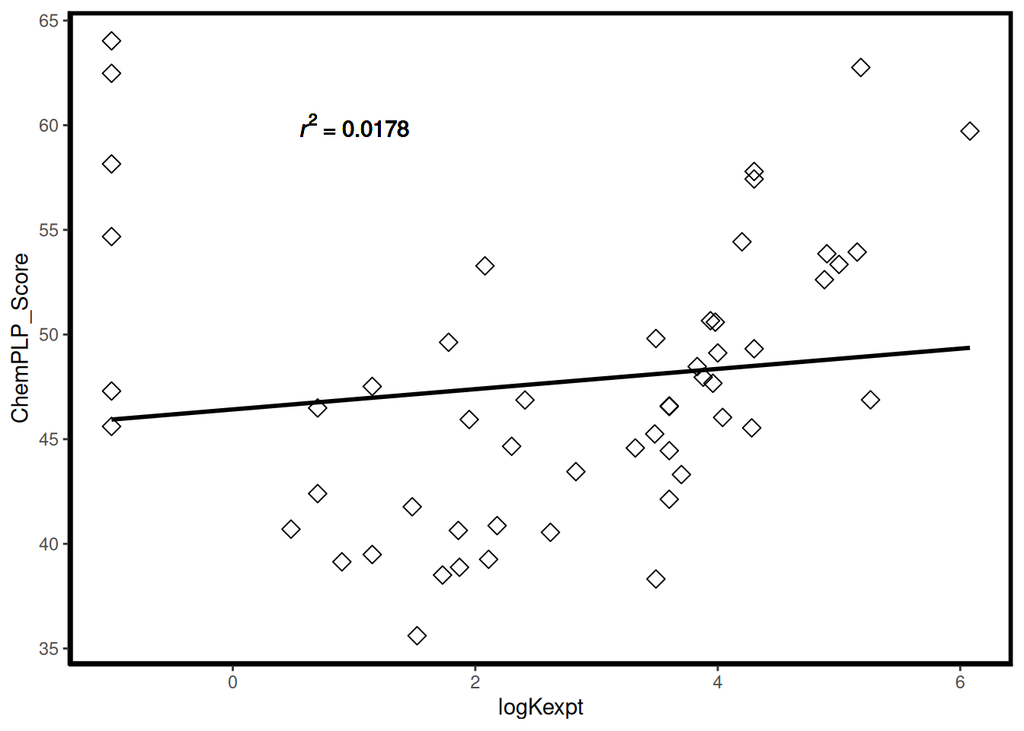

```r
lm_rsq <- function(mod){
    m <- mod;
    rsq <- substitute(italic(r)^2~"="~r2,
         list(r2 = format(summary(m)$r.squared, digits = 3)))
    as.character(as.expression(rsq));
}

ggplot(data = df_chemplp_score, aes(x=logKexpt, y=ChemPLP_Score)) +
  geom_point(size=3, shape=23) +
  theme(axis.line = element_line(colour = "black"),
    panel.grid.major = element_blank(),
    panel.grid.minor = element_blank(),
    panel.border = element_rect(color = 'black',
                                    fill = NA,
                                    size = 2),
    panel.background = element_blank()) +
  geom_smooth(method = "lm", se=FALSE, color="black", formula = y ~ x) +
  geom_text(x = 1, y = 60, label = lm_rsq(corr_man), parse = TRUE)
```

### Multivariate linear regression on the training set from the manuscript using eq. 2

The eq.2 includes molecular descriptors calculated in Gold. Then we slice our data set as in the manuscript and check dimensions.

```r
df_train <- df[1:54,]
df_test <- df[55:69,]
print("Dimensions of training set")
```

```
## [1] "Dimensions of training set"
```

```r
print(dim(df_train))
```

```
## [1] 54  7
```

```r
print("Dimensions of test set")
```

```
## [1] "Dimensions of test set"
```

```r
print(dim(df_test))
```

```
## [1] 15  7
```

We run our regression model calculating a correct analysis of the model by plotting logKexp vs. logKcalc and calculating the rmse. This allows us to test our hypothesis, that we can use the molecular descriptors calculated in Gold to build our own predictive model for cage-guest binding and evaluate the model.

```r
# no ligand_flexibility
eq2_lm = lm(logKexp~Ligand_clash + Ligand_torsion + Part_buried + Non.polar,data = df_train)
summary(eq2_lm)
```

```
##
## Call:
## lm(formula = logKexp ~ Ligand_clash + Ligand_torsion + Part_buried +
##     Non.polar, data = df_train)
##
## Residuals:
##     Min      1Q  Median      3Q     Max
## -5.0396 -0.7326  0.6488  1.1804  2.1094
##
## Coefficients:
##                Estimate Std. Error t value Pr(>|t|)
## (Intercept)      1.1812     2.0172   0.586   0.5609
## Ligand_clash    -4.2954     2.1439  -2.004   0.0507 .
## Ligand_torsion  -2.3586     1.4062  -1.677   0.0998 .
## Part_buried      0.2338     0.3260   0.717   0.4767
## Non.polar       -0.0586     0.0365  -1.605   0.1148
## ---
## Signif. codes:  0 '***' 0.001 '**' 0.01 '*' 0.05 '.' 0.1 ' ' 1
##
## Residual standard error: 1.743 on 49 degrees of freedom
## Multiple R-squared:  0.1994, Adjusted R-squared:  0.134
## F-statistic:  3.05 on 4 and 49 DF,  p-value: 0.02535
```

```r
logKcalc = predict(eq2_lm, df_train)
```

```r
df_train["logKcalc"] = logKcalc
rmse_value <- rmse(df_train$logKcalc, df_train$logKexp)
```

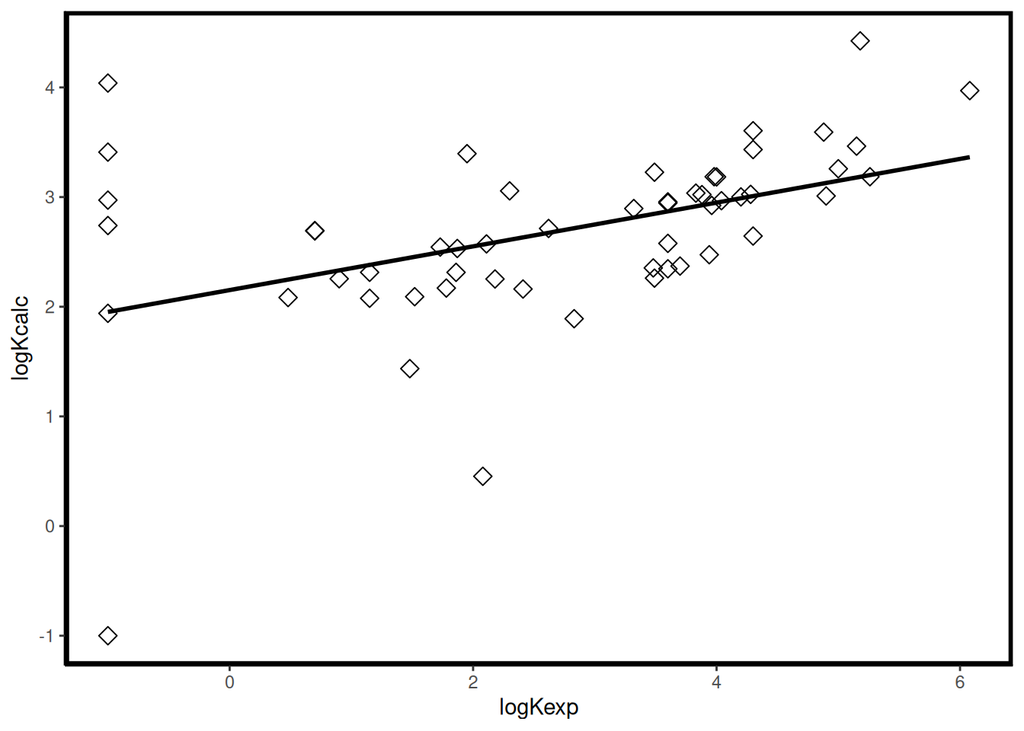

```r
ggplot(data = df_train, aes(x=logKexp, y=logKcalc)) +
  geom_point(size=3, shape=23) +
  theme(axis.line = element_line(colour = "black"),
    panel.grid.major = element_blank(),
    panel.grid.minor = element_blank(),
    panel.border = element_rect(color = 'black',
                                    fill = NA,
                                    size = 2),
    panel.background = element_blank()) +
  geom_smooth(method = "lm", se=FALSE, color="black", formula = y ~ x) +
  geom_text(x = 1, y = -2, label = rmse_value, parse = TRUE)
```

```r
paste("rmse = ", rmse_value)
```

```
## [1] "rmse =  1.65994233649364"
```

### Multivariate linear regression on the training set from the manuscript using eq. 3

The eq.3 includes a molecular descriptor for ligand flexibility this was calculated outside of gold. Then we slice our data set as in the manuscript and check dimensions.

```r
df_train <- df[1:54,]
df_test <- df[55:69,]
print("Dimensions of training set")
```

```
## [1] "Dimensions of training set"
```

```r
print(dim(df_train))
```

```
## [1] 54  7
```

```r
print("Dimensions of test set")
```

```
## [1] "Dimensions of test set"
```

```r
print(dim(df_test))
```

```
## [1] 15  7
```

Then run our regression model calculating a correct analysis of the model by plotting logKexp vs. logKcalc and calculating the rmse. This allows us to test our hypothesis, that we can use the molecular descriptors calculated in Gold to build our own predictive model for cage-guest binding and evaluate the model.

```r
# with ligand_flexibility
eq3_lm = lm(logKexp~Ligand_clash + Ligand_torsion + Part_buried + Non.polar
             + Ligand_flexibility, data = df_train)
summary(eq3_lm)
```

```
##
## Call:
## lm(formula = logKexp ~ Ligand_clash + Ligand_torsion + Part_buried +
##     Non.polar + Ligand_flexibility, data = df_train)
##
## Residuals:
##      Min       1Q   Median       3Q      Max
## -2.15219 -0.44870  0.05203  0.48009  1.53195
##
## Coefficients:
##                    Estimate Std. Error t value Pr(>|t|)
## (Intercept)        -3.00442    0.95919  -3.132  0.00295 **
## Ligand_clash       -2.55759    0.97577  -2.621  0.01170 *
## Ligand_torsion      0.48438    0.66695   0.726  0.47121
## Part_buried        -0.17865    0.15012  -1.190  0.23990
## Non.polar          -0.15505    0.01788  -8.670 2.18e-11 ***
## Ligand_flexibility -0.99953    0.07204 -13.875  < 2e-16 ***
## ---
## Signif. codes:  0 '***' 0.001 '**' 0.01 '*' 0.05 '.' 0.1 ' ' 1
##
## Residual standard error: 0.7865 on 48 degrees of freedom
## Multiple R-squared:  0.8402, Adjusted R-squared:  0.8236
## F-statistic: 50.48 on 5 and 48 DF,  p-value: < 2.2e-16
```

```r
logKcalc = predict(eq3_lm, df_train)
```

```r
df_train["logKcalc"] = logKcalc
rmse_value <- rmse(df_train$logKcalc, df_train$logKexp)
```

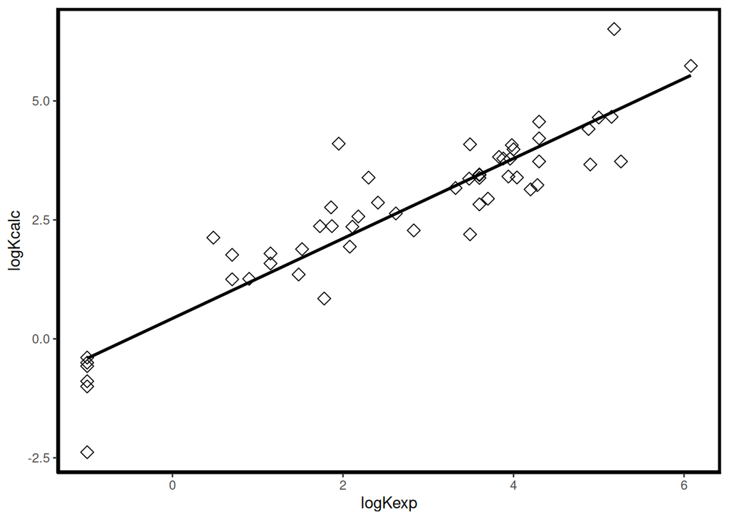

```r
ggplot(data = df_train, aes(x=logKexp, y=logKcalc)) +
  geom_point(size=3, shape=23) +
  theme(axis.line = element_line(colour = "black"),
    panel.grid.major = element_blank(),
    panel.grid.minor = element_blank(),
    panel.border = element_rect(color = 'black',
                                    fill = NA,
                                    size = 2),
    panel.background = element_blank()) +
  geom_smooth(method = "lm", se=FALSE, color="black", formula = y ~ x)
```

```r
paste("rmse = ", rmse_value)
```

```
## [1] "rmse =  0.741559548236673"
```

### Analysis of new guests from the manuscripts

To rapidly test our model we computationaly screened the labs inventory using the eq. 3 model to quickly find molecules to test the predictive model with.

```r
logKcalc_test = predict(eq3_lm, df_test)
```

```r
df_test["logKcalc"] = logKcalc_test
rmse_value <- rmse(df_test$logKcalc, df_test$logKexp)
```

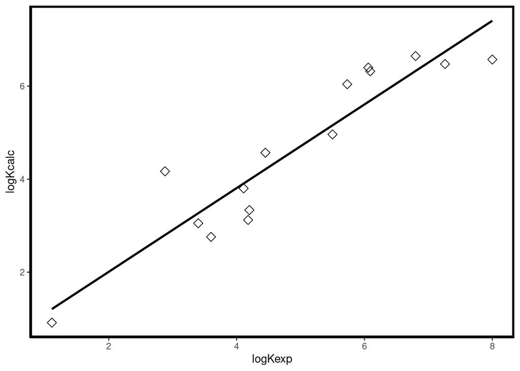

```r
ggplot(data = df_test, aes(x=logKexp, y=logKcalc)) +
  geom_point(size=3, shape=23) +
  theme(axis.line = element_line(colour = "black"),
    panel.grid.major = element_blank(),
    panel.grid.minor = element_blank(),
    panel.border = element_rect(color = 'black',
                                    fill = NA,
                                    size = 2),
    panel.background = element_blank()) +
  geom_smooth(method = "lm", se=FALSE, color="black", formula = y ~ x) #+
```

```r
  #geom_text(x = 1, y = -2, label = rmse_value, parse = TRUE)
paste("rmse = ", rmse_value)
```

```
## [1] "rmse =  0.718061998611351"
```

## Modern data science approach using eq. 3

### Run some exploratory data analysis

#### Data summary

```r
summary(df)
```

```
##      Guest     Ligand_clash     Ligand_torsion    Part_buried
##  Min.   : 1   Min.   :0.00000   Min.   :0.0000   Min.   :-4.621
##  1st Qu.:18   1st Qu.:0.00000   1st Qu.:0.0000   1st Qu.:-3.046
##  Median :35   Median :0.00000   Median :0.0000   Median :-2.193
##  Mean   :35   Mean   :0.02582   Mean   :0.0650   Mean   :-2.027
##  3rd Qu.:52   3rd Qu.:0.00000   3rd Qu.:0.0016   3rd Qu.:-1.708
##  Max.   :69   Max.   :1.78130   Max.   :1.0855   Max.   : 8.908
##    Non.polar      Ligand_flexibility    logKexp
##  Min.   :-72.20   Min.   :0.0000     Min.   :-1.000
##  1st Qu.:-49.49   1st Qu.:0.0000     1st Qu.: 1.860
##  Median :-40.64   Median :0.0000     Median : 3.600
##  Mean   :-42.43   Mean   :0.7971     Mean   : 3.167
##  3rd Qu.:-34.32   3rd Qu.:1.0000     3rd Qu.: 4.300
##  Max.   :-22.77   Max.   :7.0000     Max.   : 8.000
```

we still have guest number the data frame we will remove it

```r
 df <- df[-c(1)]
 summary(df)
```

```
##   Ligand_clash     Ligand_torsion    Part_buried       Non.polar
##  Min.   :0.00000   Min.   :0.0000   Min.   :-4.621   Min.   :-72.20
##  1st Qu.:0.00000   1st Qu.:0.0000   1st Qu.:-3.046   1st Qu.:-49.49
##  Median :0.00000   Median :0.0000   Median :-2.193   Median :-40.64
##  Mean   :0.02582   Mean   :0.0650   Mean   :-2.027   Mean   :-42.43
##  3rd Qu.:0.00000   3rd Qu.:0.0016   3rd Qu.:-1.708   3rd Qu.:-34.32
##  Max.   :1.78130   Max.   :1.0855   Max.   : 8.908   Max.   :-22.77
##  Ligand_flexibility    logKexp
##  Min.   :0.0000     Min.   :-1.000
##  1st Qu.:0.0000     1st Qu.: 1.860
##  Median :0.0000     Median : 3.600
##  Mean   :0.7971     Mean   : 3.167
##  3rd Qu.:1.0000     3rd Qu.: 4.300
##  Max.   :7.0000     Max.   : 8.000
```

#### Histogram with KDE line for clarity

The histogram is in blue bars. The Kernel Density Estimation line is and estimation of the histogram represented as a continuous line and is shown as a black line.

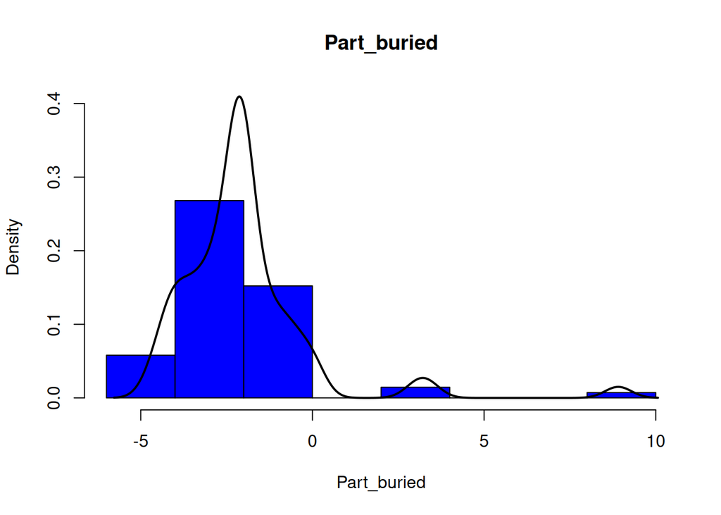

```r
hist_kde(df, "Part_buried")
```

Its helpful to plot all dataframe columns

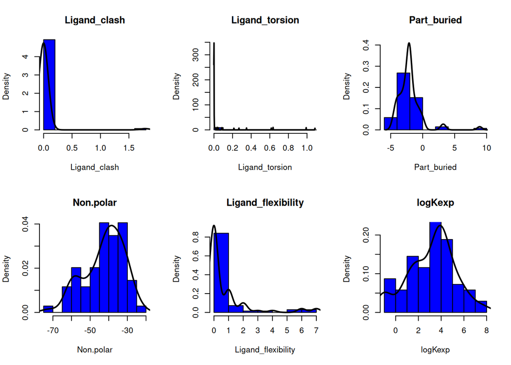

```r
multi_plot(df, hist_kde)
```

#### Correlation matrix heatmap

Over correlated molecular descriptor (GoldPLP functions) columns can cause problems with our regression models. Too many correlated molecular descriptor cause a misrepresentation of those molecular descriptors in our regression model.

```r
cor_mat <- round(cor(df),2)
head(cor_mat)
```

```
##                    Ligand_clash Ligand_torsion Part_buried Non.polar
## Ligand_clash               1.00          -0.02        0.68     -0.19
## Ligand_torsion            -0.02           1.00        0.15     -0.24
## Part_buried                0.68           0.15        1.00     -0.61
## Non.polar                 -0.19          -0.24       -0.61      1.00
## Ligand_flexibility         0.02           0.36       -0.01     -0.26
## logKexp                   -0.25          -0.06        0.20     -0.46
##                    Ligand_flexibility logKexp
## Ligand_clash                     0.02   -0.25
## Ligand_torsion                   0.36   -0.06
## Part_buried                     -0.01    0.20
## Non.polar                       -0.26   -0.46
## Ligand_flexibility               1.00   -0.58
## logKexp                         -0.58    1.00
```

Reshape our dataframe

```r
melted_cor_mat <- melt(cor_mat)
head(melted_cor_mat)
```

```
##                 Var1         Var2 value
## 1       Ligand_clash Ligand_clash  1.00
## 2     Ligand_torsion Ligand_clash -0.02
## 3        Part_buried Ligand_clash  0.68
## 4          Non.polar Ligand_clash -0.19
## 5 Ligand_flexibility Ligand_clash  0.02
## 6            logKexp Ligand_clash -0.25
```

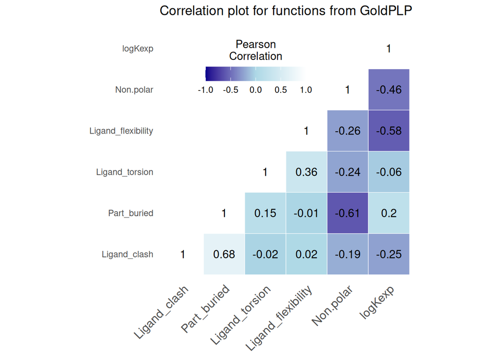

```r
correl_mat_plot_2(df, "Correlation plot for functions from GoldPLP")
```

You can make your correlation plot neater but they are not really pretty.

### Normalise our df

```r
head(df)
```

```
##   Ligand_clash Ligand_torsion Part_buried Non.polar Ligand_flexibility logKexp
## 1            0              0     -2.1090  -43.3137                  0    3.49
## 2            0              0     -3.0465  -27.4388                  0    1.15
## 3            0              0     -2.4099  -41.2634                  0    3.83
## 4            0              0     -2.2600  -32.0514                  0    1.87
## 5            0              0     -2.7351  -40.6438                  0    3.96
## 6            0              0     -3.1134  -27.9508                  0    1.52
```

```r
process <- preProcess(as.data.frame(df[1:5]), method=c("range"))
df[1:5] <- predict(process, as.data.frame(df[1:5]))
```

```r
head(df)
```

```
##   Ligand_clash Ligand_torsion Part_buried Non.polar Ligand_flexibility logKexp
## 1            0              0   0.1856960 0.5844633                  0    3.49
## 2            0              0   0.1164009 0.9056394                  0    1.15
## 3            0              0   0.1634551 0.6259443                  0    3.83
## 4            0              0   0.1745349 0.8123187                  0    1.87
## 5            0              0   0.1394180 0.6384799                  0    3.96
## 6            0              0   0.1114560 0.8952808                  0    1.52
```

### A random forest decision tree method

#### Splitting our data in to training and test sets

```r
set.seed(89)
sample <- sample.int(n = nrow(df), size = floor(.80*nrow(df)), replace = F)
train <- df[sample, ]
test  <- df[-sample, ]
print("Dimensions of training set")
```

```
## [1] "Dimensions of training set"
```

```r
print(dim(train))
```

```
## [1] 55  6
```

```r
print("Dimensions of test set")
```

```
## [1] "Dimensions of test set"
```

```r
print(dim(test))
```

```
## [1] 14  6
```

#### Fit our regression model

Fit our regression model and produce a description of the model, be-aware this is not the analysis of our model.

```r
logK.rf <- randomForest(logKexp ~ ., data = train, mtry = 3, importance = TRUE)
print(logK.rf)
```

```
##
## Call:
##  randomForest(formula = logKexp ~ ., data = train, mtry = 3, importance = TRUE)
##                Type of random forest: regression
##                      Number of trees: 500
## No. of variables tried at each split: 3
##
##           Mean of squared residuals: 1.74384
##                     % Var explained: 54.33
```

#### Plot logKexp vs logKcalc

Then run our regression model calculating a correct analysis of the model by plotting logKexp vs. logKcalc and calculating the rmse. This allows us to test our hypothesis, that we can use the molecular descriptors calculated in Gold to build our own predictive model for cage-guest binding and evaluate the model.

```r
train["logKcalc"] <- predict(logK.rf, train)
```

```r
rmse_value <- rmse(train$logKcalc, train$logKexp)
```

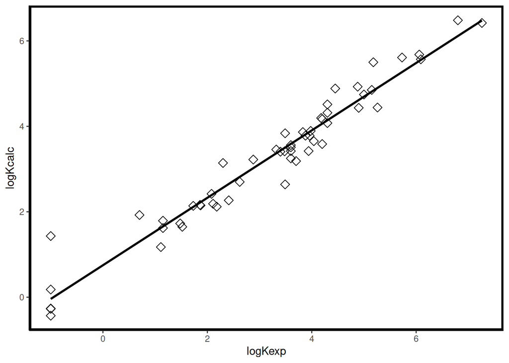

```r
ggplot(data = train, aes(x=logKexp, y=logKcalc)) +
  geom_point(size=3, shape=23) +
  theme(axis.line = element_line(colour = "black"),
    panel.grid.major = element_blank(),
    panel.grid.minor = element_blank(),
    panel.border = element_rect(color = 'black',
                                    fill = NA,
                                    size = 2),
    panel.background = element_blank()) +
  geom_smooth(method = "lm", se=FALSE, color="black", formula = y ~ x) +
  geom_text(x = 1, y = -2, label = rmse_value, parse = TRUE)
```

```r
paste("rmse = ", rmse_value)
```

```
## [1] "rmse =  0.556585579042712"
```

```r
test["logKcalc"] <- predict(logK.rf, test)
```

```r
rmse_value <- rmse(test$logKcalc, test$logKexp)
```

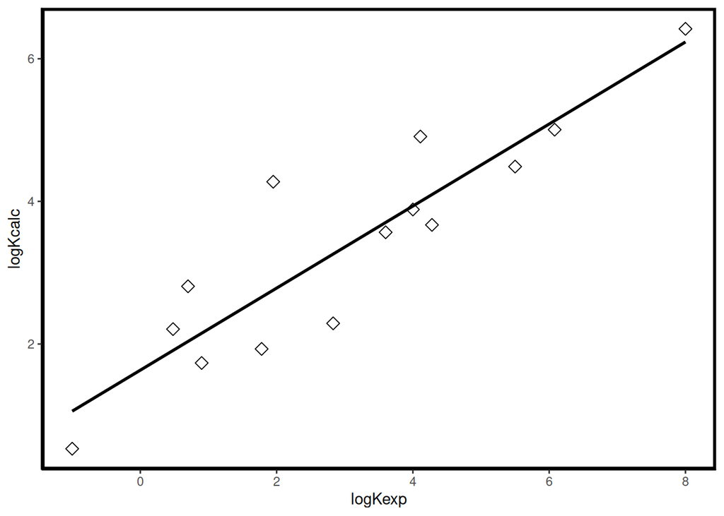

```r
ggplot(data = test, aes(x=logKexp, y=logKcalc)) +
  geom_point(size=3, shape=23) +
  theme(axis.line = element_line(colour = "black"),
    panel.grid.major = element_blank(),
    panel.grid.minor = element_blank(),
    panel.border = element_rect(color = 'black',
                                    fill = NA,
                                    size = 2),
    panel.background = element_blank()) +
  geom_smooth(method = "lm", se=FALSE, color="black", formula = y ~ x) #+
```

```r
  #geom_text(x = 1, y = -2, label = rmse_value, parse = TRUE)
  paste("rmse = ", rmse_value)
```

```
## [1] "rmse =  1.25070427079769"
```

### A Multilayer Perceptron neural networks method

#### Splitting our data in to training and test sets

```r
set.seed(89)
sample <- sample.int(n = nrow(df), size = floor(.80*nrow(df)), replace = F)
train <- df[sample, ]
test  <- df[-sample, ]
print("Dimensions of training set")
```

```
## [1] "Dimensions of training set"
```

```r
print(dim(train))
```

```
## [1] 55  6
```

```r
print("Dimensions of test set")
```

```
## [1] "Dimensions of test set"
```

```r
print(dim(test))
```

```
## [1] 14  6
```

#### Fit our regression model

Then run our regression model calculating a correct analysis of the model by plotting logKexp vs. logKcalc and calculating the rmse. This allows us to test our hypothesis, that we can use the molecular descriptors calculated in Gold to build our own predictive model for cage-guest binding and evaluate the model.

```r
# formulate eq 3 for our model
eq_3_form <- logKexp~Ligand_clash + Ligand_torsion + Part_buried + Non.polar + Ligand_flexibility
# Train the MLP model
model <- neuralnet(eq_3_form, data = train, hidden = c(5, 3), linear.output = TRUE, stepmax=1e7)
```

#### Plot logKexp vs logKcalc

```r
train["logKcalc"] <- predict(model, train)
```

```r
rmse_value <- rmse(train$logKcalc, train$logKexp)
```

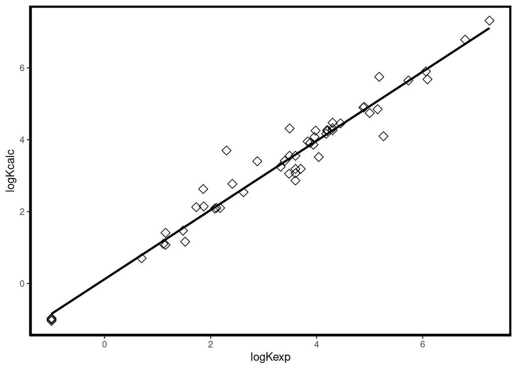

```r
ggplot(data = train, aes(x=logKexp, y=logKcalc)) +
  geom_point(size=3, shape=23) +
  theme(axis.line = element_line(colour = "black"),
    panel.grid.major = element_blank(),
    panel.grid.minor = element_blank(),
    panel.border = element_rect(color = 'black',
                                    fill = NA,
                                    size = 2),
    panel.background = element_blank()) +
  geom_smooth(method = "lm", se=FALSE, color="black", formula = y ~ x) #+
```

```r
  #geom_text(x = 1, y = -2, label = rmse_value, parse = TRUE)

paste("rmse = ", rmse_value)
```

```
## [1] "rmse =  0.381059602630145"
```

```r
test["logKcalc"] <- predict(model, test)
#head(test)
```

```r
rmse_value <- rmse(test$logKcalc, test$logKexp)
```

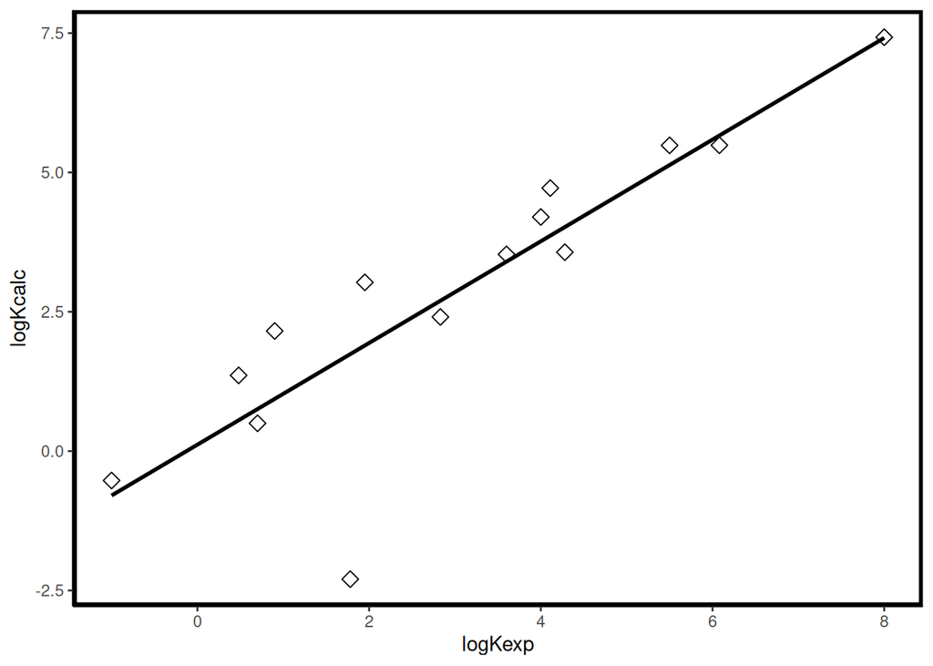

```r
ggplot(data = test, aes(x=logKexp, y=logKcalc)) +
  geom_point(size=3, shape=23) +
  theme(axis.line = element_line(colour = "black"),
    panel.grid.major = element_blank(),
    panel.grid.minor = element_blank(),
    panel.border = element_rect(color = 'black',
                                    fill = NA,
                                    size = 2),
    panel.background = element_blank()) +
  geom_smooth(method = "lm", se=FALSE, color="black", formula = y ~ x)
```

```r
paste("rmse = ", rmse_value)
```

```
## [1] "rmse =  1.2588352050018"
```